# MUSA 508 Midterm: Zillow Housing Algorithm Assignment - REVISED

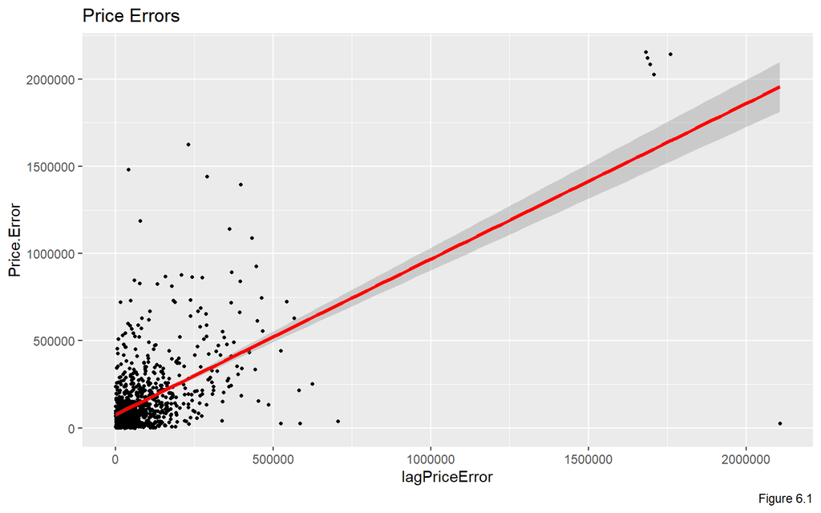

```r
TestBoulder2 <-
  TestBoulder1 %>%
  mutate(lagPriceError = lag.listw(spatialWeights.test, Price.Error, NAOK = TRUE))

TestBoulder2 <-
  TestBoulder2 %>%
  mutate(Regression = "Regression")

TestBoulder2Filter <- TestBoulder2 %>% filter(Price.Error >0,lagPriceError >0)

ggplot(data = TestBoulder2Filter, aes(lagPriceError, Price.Error)) +
  geom_point(size = .85,colour = "black") +
  geom_smooth(method = "lm",colour = "red",size = 1.2) +
  labs(title="Price Errors",
       caption = "Figure 6.1")
## `geom_smooth()` using formula 'y ~ x'
```

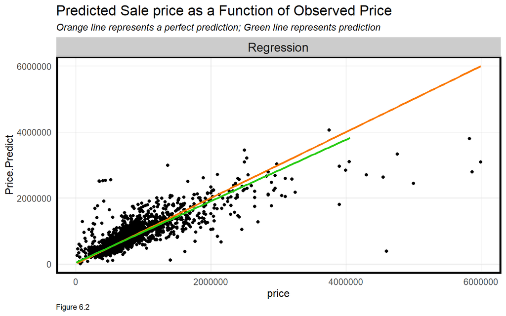

```r
# Moran's I
moranTest <- moran.mc(na.omit(TestBoulder2$Price.Error),
                      spatialWeights.test, nsim = 999)

TestBoulder2 %>%
  dplyr::select(Price.Predict, price, Regression) %>%
    ggplot(aes(price, Price.Predict)) +
  geom_point() +
  stat_smooth(aes(price, price),
             method = "lm", se = FALSE, size = 1, colour="#FA7800") +
  stat_smooth(aes(Price.Predict, price),
              method = "lm", se = FALSE, size = 1, colour="#25CB10") +
  facet_wrap(~Regression) +
  labs(title="Predicted Sale price as a Function of Observed Price",
       subtitle="Orange line represents a perfect prediction; Green line represents prediction",
       caption = "Figure 6.2") +
  plotTheme()
## `geom_smooth()` using formula 'y ~ x'
## `geom_smooth()` using formula 'y ~ x'
```

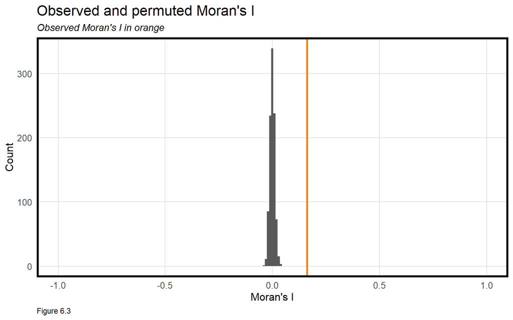

```r
ggplot(as.data.frame(moranTest$res[c(1:999)]), aes(moranTest$res[c(1:999)])) +
  geom_histogram(binwidth = 0.01) +
  geom_vline(aes(xintercept = moranTest$statistic), colour = "#FA7800",size=1) +
  scale_x_continuous(limits = c(-1, 1)) +
  labs(title="Observed and permuted Moran's I",
       subtitle= "Observed Moran's I in orange",
       caption = "Figure 6.3",
       x="Moran's I",
       y="Count") +
  plotTheme()
```

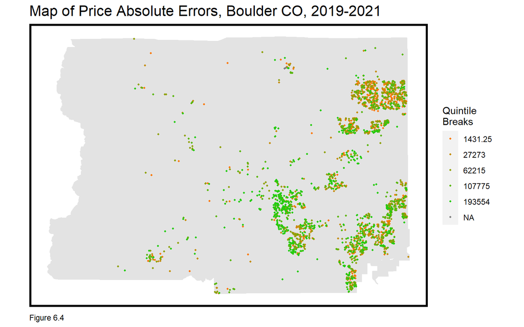

```r
ggplot() +
  geom_sf(data = Boulder.Boundary, fill = "grey89", color = "grey89") +
  geom_sf(data = TestBoulder2, aes(colour = q5(Price.AbsError)),
          show.legend = "point", size = .75) +
  scale_colour_manual(values = palette5,
                   labels=qBr(TestBoulder2,"Price.AbsError"),
                   name="Quintile\nBreaks") +
  labs(title="Map of Price Absolute Errors, Boulder CO, 2019-2021",
      caption="Figure 6.4") +
  mapTheme()
```

# Neighborhood

We wanted to include a spatial variable to represent a neighborhood to understand neighborhood character and in this case. In our model, we use Census Block Groups as it was the data that was readily available and accessible at the time. Block Groups turned out to be a significant variable in the model–explaining about 10% more variance than a model without it.

```r
TestBoulder2 %>%
  st_drop_geometry() %>%
    group_by(Geo_QName) %>%
    summarize(meanPrice = mean(price, na.rm = T),
            meanPrediction = mean(Price.Predict)) %>%
      kable(caption = "Price and Prediction by block group (Figure 7.1)") %>% kable_styling("striped", full_width = F) %>% scroll_box(width = "800px", height = "500px")
```

Price and Prediction by block group (Figure 7.1)

| Geo_QName | meanPrice | meanPrediction |
| --- | --- | --- |
| Block Group 1, Census Tract 121.01, Boulder County, Colorado | 2389125.0 | 2164075.4 |
| Block Group 1, Census Tract 121.02, Boulder County, Colorado | 601333.3 | 683019.4 |
| Block Group 1, Census Tract 121.03, Boulder County, Colorado | 1293544.4 | 1527067.0 |
| Block Group 1, Census Tract 121.04, Boulder County, Colorado | 1116084.6 | 1550603.0 |
| Block Group 1, Census Tract 121.05, Boulder County, Colorado | 906666.7 | 911153.5 |
| Block Group 1, Census Tract 122.01, Boulder County, Colorado | 1350000.0 | 1307598.2 |
| Block Group 1, Census Tract 122.02, Boulder County, Colorado | 1079000.0 | 1019445.9 |
| Block Group 1, Census Tract 122.03, Boulder County, Colorado | 413100.0 | 2519463.0 |
| Block Group 1, Census Tract 125.01, Boulder County, Colorado | 787650.0 | 722783.4 |
| Block Group 1, Census Tract 125.05, Boulder County, Colorado | 1295300.0 | 1138758.9 |
| Block Group 1, Census Tract 125.07, Boulder County, Colorado | 706145.5 | 714662.1 |
| Block Group 1, Census Tract 125.08, Boulder County, Colorado | 749128.6 | 809383.1 |
| Block Group 1, Census Tract 125.09, Boulder County, Colorado | 944300.0 | 956569.6 |
| Block Group 1, Census Tract 125.10, Boulder County, Colorado | 2092400.0 | 1710844.4 |
| Block Group 1, Census Tract 125.11, Boulder County, Colorado | 937500.0 | 805518.3 |
| Block Group 1, Census Tract 126.03, Boulder County, Colorado | 875058.8 | 886356.7 |
| Block Group 1, Census Tract 126.08, Boulder County, Colorado | 621359.1 | 647569.8 |
| Block Group 1, Census Tract 127.01, Boulder County, Colorado | 1243500.0 | 981636.0 |
| Block Group 1, Census Tract 127.05, Boulder County, Colorado | 250200.0 | 612212.6 |
| Block Group 1, Census Tract 127.07, Boulder County, Colorado | 1085000.0 | 971106.4 |
| Block Group 1, Census Tract 127.08, Boulder County, Colorado | 613150.0 | 601196.1 |
| Block Group 1, Census Tract 127.09, Boulder County, Colorado | 671653.3 | 610436.2 |
| Block Group 1, Census Tract 127.10, Boulder County, Colorado | 1186666.7 | 1483825.9 |
| Block Group 1, Census Tract 128, Boulder County, Colorado | 982084.6 | 1001276.6 |
| Block Group 1, Census Tract 129.03, Boulder County, Colorado | 765670.8 | 811307.8 |
| Block Group 1, Census Tract 129.04, Boulder County, Colorado | 433354.2 | 432953.6 |
| Block Group 1, Census Tract 129.05, Boulder County, Colorado | 568580.0 | 544493.7 |
| Block Group 1, Census Tract 129.07, Boulder County, Colorado | 614810.5 | 524370.6 |
| Block Group 1, Census Tract 130.03, Boulder County, Colorado | 1146341.2 | 1102489.6 |
| Block Group 1, Census Tract 130.04, Boulder County, Colorado | 726687.5 | 672708.5 |

[output cut: 159 more lines]

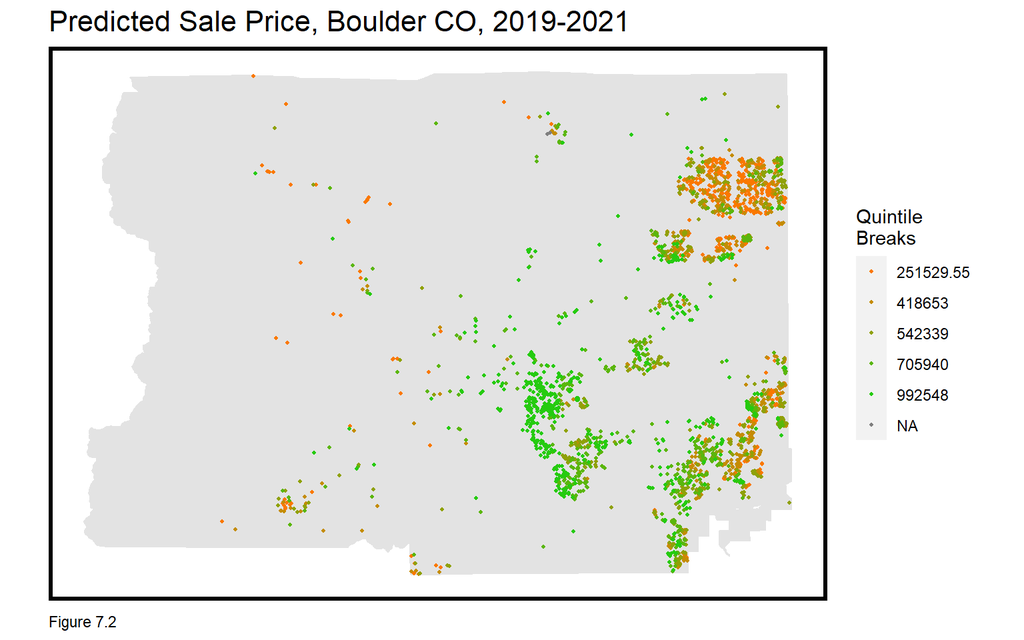

```r
# Predicted Map - Test Set
ggplot() +
  geom_sf(data = Boulder.Boundary, fill = "grey89", color = "grey89") +
  geom_sf(data = TestBoulder2, aes(colour = q5(Price.Predict)),
          show.legend = "point", size = .75) +
  scale_colour_manual(values = palette5,
                   labels=qBr(TestBoulder2,"Price.Predict"),
                   name="Quintile\nBreaks") +
  labs(title="Predicted Sale Price, Boulder CO, 2019-2021",
      caption="Figure 7.2") +
  mapTheme()
```

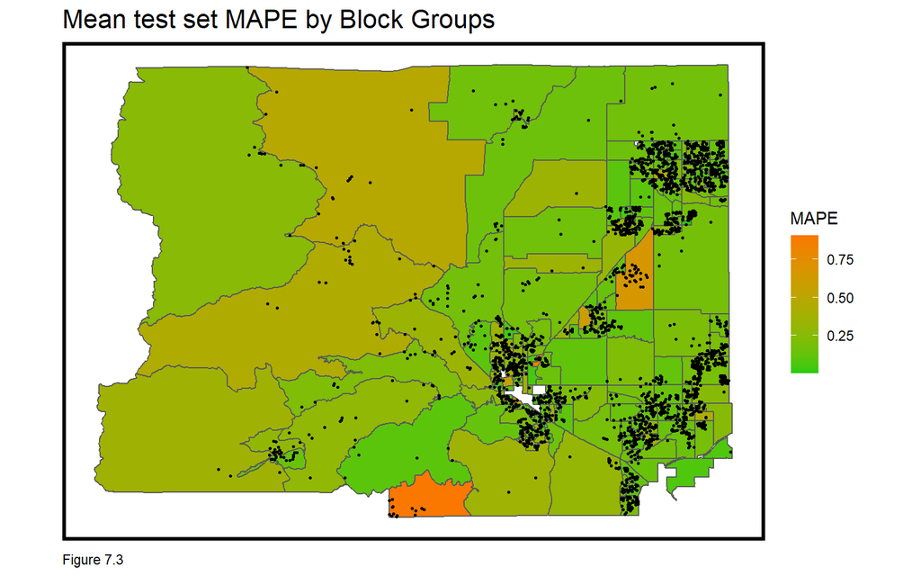

```r
st_drop_geometry(TestBoulder2) %>%
  group_by(Geo_QName) %>%
  summarize(MAPE = mean(Price.APE, na.rm = T)) %>%
  ungroup() %>%
  left_join(BoulderCensusData) %>%
    st_sf() %>%
    ggplot() +
   geom_sf(aes(fill = MAPE)) +
      scale_fill_gradient(low = palette5[5], high = palette5[1],
                          name = "MAPE") +
  geom_sf(data = TestBoulder2, colour = "black", show.legend = "point", size = .5) +
      labs(title = "Mean test set MAPE by Block Groups",
           caption = "Figure 7.3") +
      mapTheme()
## Joining, by = "Geo_QName"
```

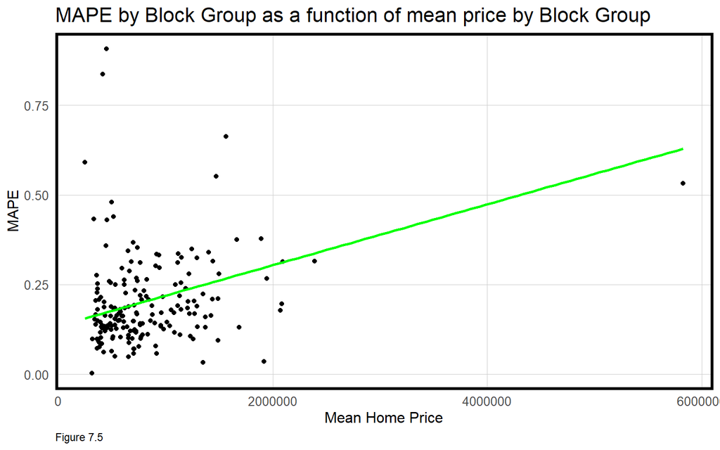

```r
TestBoulder2 <-
  TestBoulder2 %>%
  group_by(Geo_QName) %>%
  mutate(MeanPrice = mean(price))

TestBoulder2 <-
  TestBoulder2 %>%
  group_by(Geo_QName) %>%
  mutate(MAPE = mean(Price.APE))

#This now seems correct versus the old version - woo!

ggplot(TestBoulder2) +
  geom_point(aes(MeanPrice, MAPE)) +
  geom_smooth(method = "lm", aes(MeanPrice, MAPE), se = FALSE, colour = "green") +
  labs(title = "MAPE by Block Group as a function of mean price by Block Group",
       x = "Mean Home Price", y = "MAPE",
       caption = "Figure 7.5") +
  plotTheme()
## `geom_smooth()` using formula 'y ~ x'
```

```r
# can talk about these two being the outliers
```

# Tidycensus Context

Further, to evaluate our model, we wanted to explore predicted prices and errors across demographic contexts. In this case, we chose the context of race and income. This last set of analysis tells us that errors across these demographic breaks are consistent, and therefore, across these contexts, our model is pretty generalizable. That being said, Boulder CO is largely white with residents of a higher income, so this analysis applied to a different county, may have differnet results.

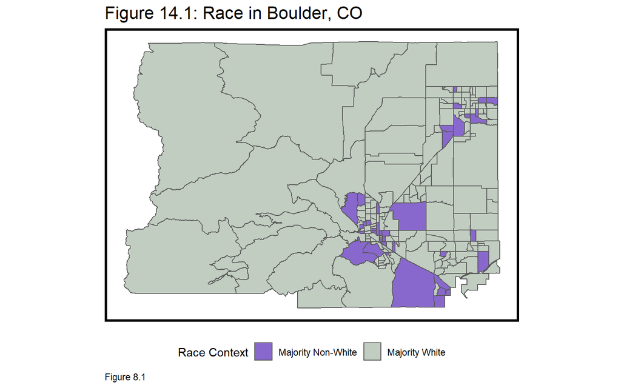

```r
Context <-
  BoulderCensusData %>%
  mutate(Race = ifelse(PerNonWhit > 15, "Majority Non-White", "Majority White"),
         Income = ifelse(MedHHInc > 80000, "High Income", "Low Income"))


ggplot() + geom_sf(data = na.omit(Context), aes(fill = Race)) +
    scale_fill_manual(values = c("medium purple 3", "honeydew 3"), name="Race Context") +
    labs(title = "Figure 14.1: Race in Boulder, CO",
         caption = "Figure 8.1") +
    mapTheme() + theme(legend.position="bottom")
```

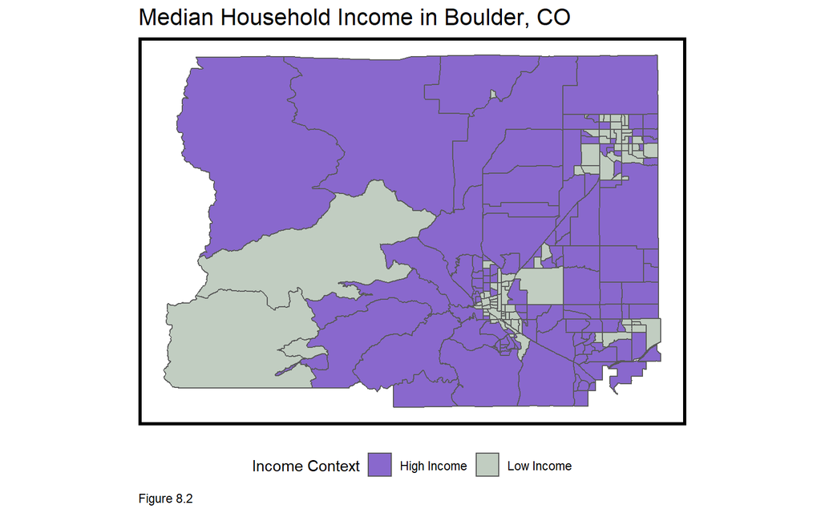

```r
ggplot() + geom_sf(data = na.omit(Context), aes(fill = Income)) +
    scale_fill_manual(values = c("medium purple 3", "honeydew 3"), name="Income Context") +
    labs(title = "Median Household Income in Boulder, CO",
         caption = "Figure 8.2") +
    mapTheme() + theme(legend.position="bottom")
```

```r
st_join(TestBoulder2, Context) %>%
  group_by(Regression, Race) %>%
  summarize(mean.MAPE = scales::percent(mean(Price.APE, na.rm = T))) %>%
  st_drop_geometry() %>%
  spread(Race, mean.MAPE) %>%
  kable(caption = "Test set MAPE by neighborhood racial context (Figure 8.3)") %>%
  kable_styling("striped",full_width = F)
## `summarise()` has grouped output by 'Regression'. You can override using the `.groups` argument.
```

Test set MAPE by neighborhood racial context (Figure 8.3)

| Regression | Majority Non-White | Majority White |
| --- | --- | --- |
| Regression | 18% | 20% |

```r
st_join(TestBoulder2, Context) %>%
  group_by(Regression, Race) %>%
  summarize(mean.PricePredict = (mean(Price.Predict, na.rm = T))) %>%
  st_drop_geometry() %>%
  spread(Race, mean.PricePredict) %>%
  kable(caption = "Mean Predicted Price by neighborhood racial context (Figure 8.4)") %>%
  kable_styling("striped",full_width = F)
## `summarise()` has grouped output by 'Regression'. You can override using the `.groups` argument.
```

Mean Predicted Price by neighborhood racial context (Figure 8.4)

| Regression | Majority Non-White | Majority White |
| --- | --- | --- |
| Regression | 731407.5 | 751152.2 |

```r
st_join(TestBoulder2, Context) %>%
  group_by(Regression, Income) %>%
  summarize(mean.MAPE = scales::percent(mean(Price.APE, na.rm = T))) %>%
  st_drop_geometry() %>%
  spread(Income, mean.MAPE) %>%
  kable(caption = "Test set MAPE by neighborhood income context (Figure 8.5)") %>%
  kable_styling("striped",full_width = F)
## `summarise()` has grouped output by 'Regression'. You can override using the `.groups` argument.
```

Test set MAPE by neighborhood income context (Figure 8.5)

| Regression | High Income | Low Income |
| --- | --- | --- |
| Regression | 20% | 19% |

```r
st_join(TestBoulder2, Context) %>%
  group_by(Regression, Income) %>%
  summarize(mean.PricePredict = (mean(Price.Predict, na.rm = T))) %>%
  st_drop_geometry() %>%
  spread(Income, mean.PricePredict) %>%
  kable(caption = "Mean Predicted Price by neighborhood income context (Figure 8.6)") %>%
  kable_styling("striped",full_width = F)
## `summarise()` has grouped output by 'Regression'. You can override using the `.groups` argument.
```

Mean Predicted Price by neighborhood income context (Figure 8.6)

| Regression | High Income | Low Income |
| --- | --- | --- |
| Regression | 797408.1 | 587106.9 |

# Discussion

Overall, our model yields some complicated, yet interesting results. It is definitely not a perfect indicator of home prices in Boulder, CO, but there are meaningful takeaways. Some of the most significant variables were ones relating to housing characteristics (like quality code), however, a few, but not as many, of the Boulder specific variables were too (like geological hazards and block groups). However, some of our variables may have still been colinear–affecting accuracy and our biggest weakess was failing to identify a variable that relates to price clustering.

In relation to accuracy, our model did not perform as well as we had liked. To recall, based on our adjusted R-Squared value, our model accounted for about 58% of the variation in home prices. Our average price error is about 150K, which is definitely a chunk of change to be off by. Further, analysis of the error charts and plots, our model struggles to predict higher priced homes. When evaluating generalizability, or the ability to apply our model to new data, we can conclude that our model definitely has errors, but functions well across demographic features. When using cross validation, we found that many of our errors clustered around the same range of prices such as $160,000-170,000, $180,000-$200,000, and $210,000-$230,000. In this cross validation, we were able to determine 70% of the home price error clusters, and it would have been better to attribute more errors. That being said, errors across the two demographic breakdowns (race and income) were consistent and this is a good indicator of generalizability across human-related variables.

# Conclusion

It is clear that there are pros and cons to our model, however, we would not recommend our model as is to Zillow and more investigation should be done on its effectiveness. Some areas of improvement would be to spend more energy thoughtfully categorizing the variables for potentially more significant analysis (for ex. potentially weighting houses with bedrooms as small/medium/large). We also would want to spend more time addressing the neighborhood effect and what makes a neighborhood more attractive in a quantifiable way, like including a price clustering variable. Lastly, we wish to have also included variables such as poverty, transportation, and crime, but they were unavailable for this case. This Boulder specific data could have helped us create a model with potentially a more community oriented lens Overall, the model raises very interesting questions about what attributes to a home price!